# IODS course project

## LDA with clusters as target classes

Next, we will fit and LDA model to the scaled Boston data using clusters from k-means clustering as target classes. We will first run the k-means algorithm (this time for 3 clusters), then include the cluster labels in our scaled data set, and then fit LDA with clusters as the target classes and all other variables as predictors. Finally, we will visualize the results with a biplot.

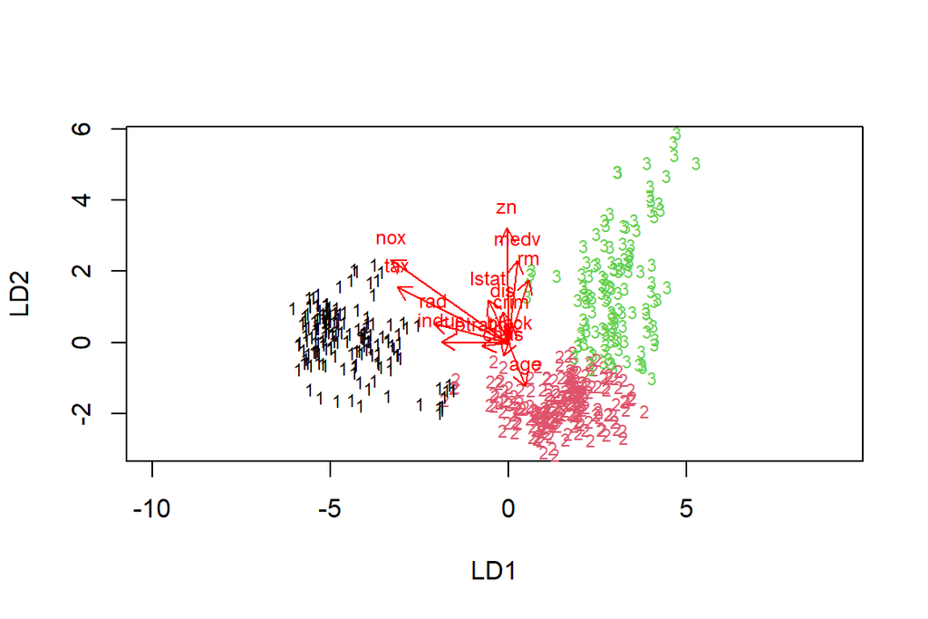

```r
# reload the data, not strictly necessary as there were no changes to this data frame previously
data("Boston")

# setting seed for replicability
set.seed(1)

# standardizing the data set and changing to data frame
boston_scaled <- as.data.frame(scale(Boston))

# k-means clustering with 3 clusters
km <- kmeans(boston_scaled, centers = 3)

# include clusters in the boston data frame
boston_scaled$cluster <- km$cluster

# fit linear discriminant analysis
lda.fit <- lda(cluster ~ ., data = boston_scaled)

# the function for lda biplot arrows
lda.arrows <- function(x, myscale = 1, arrow_heads = 0.1, color = "red", tex = 0.75, choices = c(1,2)){
  heads <- coef(x)
  arrows(x0 = 0, y0 = 0,
         x1 = myscale * heads[,choices[1]],
         y1 = myscale * heads[,choices[2]], col=color, length = arrow_heads)
  text(myscale * heads[,choices], labels = row.names(heads),
       cex = tex, col=color, pos=3)
}

# target classes as numeric
classes <- as.numeric(boston_scaled$cluster)

# plot the lda results
plot(lda.fit, dimen = 2, col = classes, pch = classes)
lda.arrows(lda.fit, myscale = 3)
```

```
## [1] "Last updated Tue Dec 13 16:48:52 2022"
```

# Assignment 5: Dimensionality reduction techniques

In this assignment we will use data combined from from Human Development Index and Gender Inequality Index data sets (for details, see https://hdr.undp.org/data-center/human-development-index#/indicies/HDI and https://hdr.undp.org/system/files/documents//technical-notes-calculating-human-development-indices.pdf). To begin with, we will explore the data visually and through variable summaries.

```r
# load in packages for future use, suppress output to keep course diary page tidy
library(readr) # install.packages("readr")
library(GGally) # install.packages("GGally")
library(dplyr) # install.packages("dplyr")
library(FactoMineR) # install.packages("FactoMineR")
```

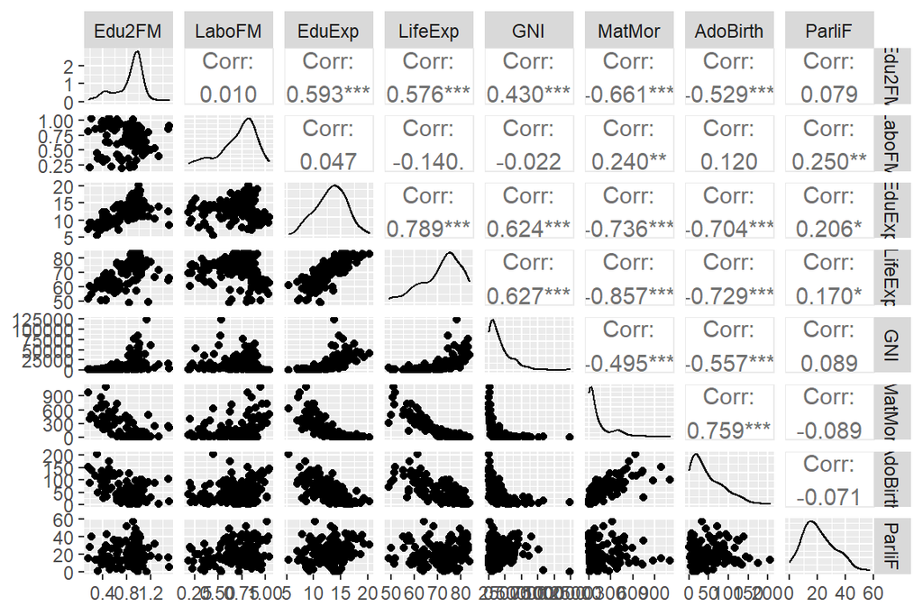

```r
# load the data
human <- read.csv("data/human.csv", header = T, row.names = 1, sep = ",")

# explore the dataset
ggpairs(human, progress = FALSE)
```

```r
summary(human)
```

```
##      Edu2FM           LaboFM           EduExp         LifeExp
##  Min.   :0.1717   Min.   :0.1857   Min.   : 5.40   Min.   :49.00
##  1st Qu.:0.7264   1st Qu.:0.5984   1st Qu.:11.25   1st Qu.:66.30
##  Median :0.9375   Median :0.7535   Median :13.50   Median :74.20
##  Mean   :0.8529   Mean   :0.7074   Mean   :13.18   Mean   :71.65
##  3rd Qu.:0.9968   3rd Qu.:0.8535   3rd Qu.:15.20   3rd Qu.:77.25
##  Max.   :1.4967   Max.   :1.0380   Max.   :20.20   Max.   :83.50
##       GNI             MatMor          AdoBirth          ParliF
##  Min.   :   581   Min.   :   1.0   Min.   :  0.60   Min.   : 0.00
##  1st Qu.:  4198   1st Qu.:  11.5   1st Qu.: 12.65   1st Qu.:12.40
##  Median : 12040   Median :  49.0   Median : 33.60   Median :19.30
##  Mean   : 17628   Mean   : 149.1   Mean   : 47.16   Mean   :20.91
##  3rd Qu.: 24512   3rd Qu.: 190.0   3rd Qu.: 71.95   3rd Qu.:27.95
##  Max.   :123124   Max.   :1100.0   Max.   :204.80   Max.   :57.50
```

We find that there are numerous high correlations between our variables. The correlations between, e.g., gender ratio for population with secondary eduation (Edu2FM), expected years of education (EduExp), life expectancy at birth (LifeExp) and Gross National Income per capita (GNI) are positive, and these variables are negatively correlated with maternal mortality ratio (MatMor) and adolescent birth rate (AdoBirth). Of the variables EduExp and ParliF could be considered fairly normally distributed, but the rest of the variables are more or less skewed. Variable summaries also show us that the variables are on very different scales. Especially GNI is of a much higher magnitude than the rest of the variables.

## Principal component analysis (unstandardized)

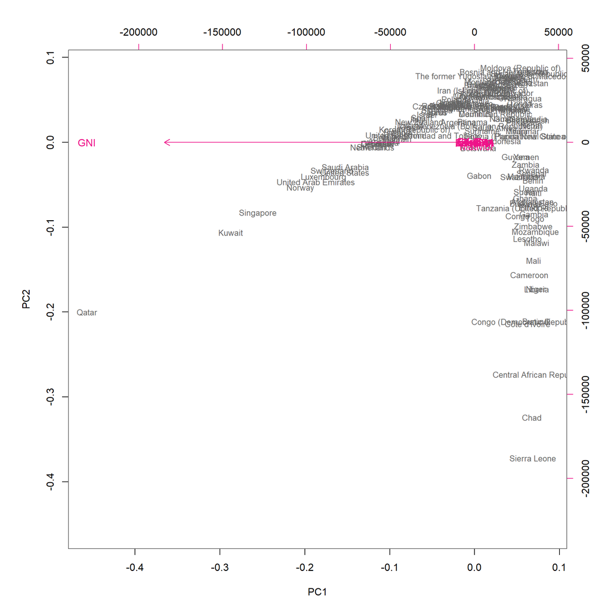

Figure: A biplot of PCA on unstandardized variables relating to human development and gender inequality of countries. PC1 coordinate is plotted on x-axis, PC2 coordinate is plotted on y-axis. Due to its large variation, Gross National Income per capita (GNI) is the only variable that is clearly distinguishable. Countries mostly align on two trajectories, one of which is captured by PC2, and one that is a combination of PC1 and PC2.

```r
# perform principal component analysis (with the SVD method)
pca_human <- prcomp(human)

# draw a biplot of the principal component representation and the original variables
biplot(pca_human, choices = 1:2, cex = c(0.8, 1), col = c("grey40", "deeppink2"))
```

Plotting the observations with weight on the first principal component on x-axis, and weight on the second principal component on y-axis, we can see that both axes provide some clear separation between countries. A majority of the countries, however, are packed within a relatively small area. It is also clear that because the variable GNI has a much larger variation, it dwarves the other variables in scale, which are indiscriminable in this graph.

## Principal component analysis (standardized)

We will now standardize the variables and repeat the PCA.

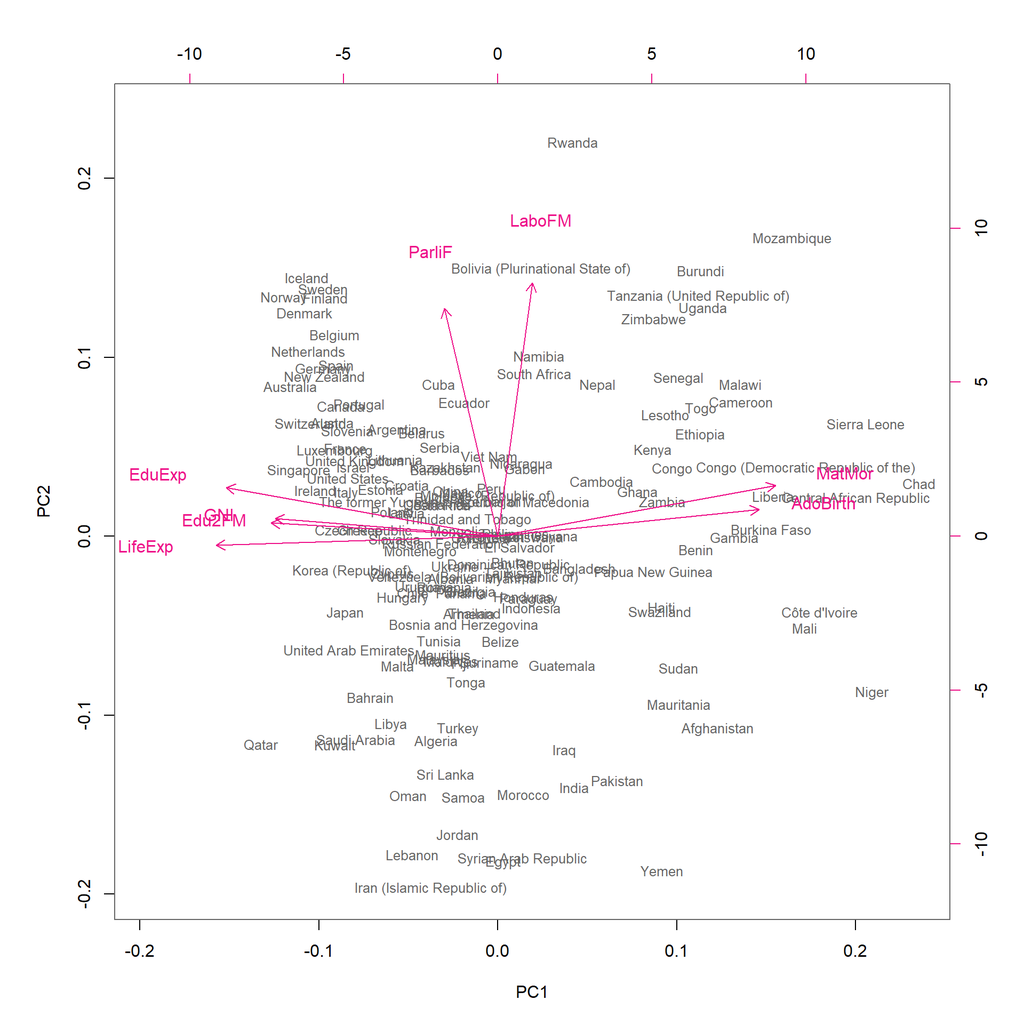

Figure: A biplot of PCA on standardized variables relating to human development and gender inequality of countries. PC1 coordinate is plotted on x-axis, PC2 coordinate is plotted on y-axis. Gender ratio for population with secondary eduation, expected years of education, life expectancy at birth, and Gross National Income per capita seem to go together within countries. This seems to reflect a general state of development of the country. Opposite to the previous are maternal mortality and adolescent birth rate. It appears reproductive health is clearly negatively correlated with the country’s development. Orthogonal to the other are ratio of female participation in parliament and labour force. However, there is some division between these two, as female participation in labour force seems more common in less developed countries than female participation in parliament, and vice versa.

```r
# standardize the variables
human_std <- as.data.frame(scale(human))

# perform principal component analysis (with the SVD method)
pca_human <- prcomp(human_std)

# draw a biplot of the principal component representation and the original variables
biplot(pca_human, choices = 1:2, cex = c(0.8, 1), col = c("grey40", "deeppink2"))
```

Now, with standardized variables, the biplot is much more descriptive. We can see that the result is not only in different scale, but also fairly different. Because the variables now have the same variation, they contribute much more equally to the PCA which tries to account for total variation. If we were to interpret the principal components, we could say that principal component 1 represents a general state of human development, and principal component 2 represents female participation in society.

## Multiple Correspondence Analysis of tea data

Next, we will examine selected variables from the “tea” data set, included in the FactoMineR package. The variables were selected with the main interest of looking whether different age groups or genders form specific groups on the basis of their tea drinking habits; specifically, whether they drink tea with or without friends, at home or outside home, in the evening or at breakfast, and whether they have a specific tea time (as I interpret the variable). We will perform MCA, print out a summary of the model, and plot our results on the first two MCA dimensions.

```r
# load data set
tea <- read.csv("https://raw.githubusercontent.com/KimmoVehkalahti/Helsinki-Open-Data-Science/master/datasets/tea.csv", stringsAsFactors = TRUE)

# look at dimensions and structure
dim(tea)
```

```
## [1] 300  36
```

```r
str(tea)
```

```
## 'data.frame':    300 obs. of  36 variables:
##  $ breakfast       : Factor w/ 2 levels "breakfast","Not.breakfast": 1 1 2 2 1 2 1 2 1 1 ...
##  $ tea.time        : Factor w/ 2 levels "Not.tea time",..: 1 1 2 1 1 1 2 2 2 1 ...
##  $ evening         : Factor w/ 2 levels "evening","Not.evening": 2 2 1 2 1 2 2 1 2 1 ...
##  $ lunch           : Factor w/ 2 levels "lunch","Not.lunch": 2 2 2 2 2 2 2 2 2 2 ...
##  $ dinner          : Factor w/ 2 levels "dinner","Not.dinner": 2 2 1 1 2 1 2 2 2 2 ...
##  $ always          : Factor w/ 2 levels "always","Not.always": 2 2 2 2 1 2 2 2 2 2 ...
##  $ home            : Factor w/ 2 levels "home","Not.home": 1 1 1 1 1 1 1 1 1 1 ...
##  $ work            : Factor w/ 2 levels "Not.work","work": 1 1 2 1 1 1 1 1 1 1 ...
##  $ tearoom         : Factor w/ 2 levels "Not.tearoom",..: 1 1 1 1 1 1 1 1 1 2 ...
##  $ friends         : Factor w/ 2 levels "friends","Not.friends": 2 2 1 2 2 2 1 2 2 2 ...
##  $ resto           : Factor w/ 2 levels "Not.resto","resto": 1 1 2 1 1 1 1 1 1 1 ...
##  $ pub             : Factor w/ 2 levels "Not.pub","pub": 1 1 1 1 1 1 1 1 1 1 ...
##  $ Tea             : Factor w/ 3 levels "black","Earl Grey",..: 1 1 2 2 2 2 2 1 2 1 ...
##  $ How             : Factor w/ 4 levels "alone","lemon",..: 1 3 1 1 1 1 1 3 3 1 ...
```

[output cut: 22 more lines]

```r
# view data
# View(tea)

# column names to keep in the dataset
keep_columns <- c("tea.time", "breakfast", "evening", "home", "friends", "age_Q", "sex")

# select the 'keep_columns' to create a new dataset
tea_time <- dplyr::select(tea, one_of(keep_columns))

# multiple correspondence analysis
mca <- MCA(tea_time, graph = FALSE)

# summary of the model
summary(mca)
```

```
##
## Call:
## MCA(X = tea_time, graph = FALSE)
##
##
## Eigenvalues
##                        Dim.1   Dim.2   Dim.3   Dim.4   Dim.5   Dim.6   Dim.7
## Variance               0.225   0.194   0.161   0.150   0.142   0.140   0.119
## % of var.             15.764  13.557  11.251  10.502   9.954   9.775   8.344
## Cumulative % of var.  15.764  29.321  40.573  51.075  61.029  70.804  79.148
##                        Dim.8   Dim.9  Dim.10
## Variance               0.112   0.105   0.081
## % of var.              7.845   7.355   5.653
## Cumulative % of var.  86.993  94.347 100.000
##
## Individuals (the 10 first)
##                  Dim.1    ctr   cos2    Dim.2    ctr   cos2    Dim.3    ctr
## 1             |  0.469  0.325  0.120 |  0.629  0.681  0.217 | -0.510  0.540
## 2             |  0.194  0.056  0.028 |  0.812  1.134  0.490 | -0.101  0.021
## 3             | -0.436  0.282  0.152 | -0.254  0.111  0.051 |  0.384  0.306
## 4             |  0.529  0.415  0.234 |  0.107  0.020  0.010 | -0.012  0.000
## 5             |  0.591  0.518  0.212 |  0.280  0.135  0.047 | -0.354  0.259
## 6             |  0.529  0.415  0.234 |  0.107  0.020  0.010 | -0.012  0.000
## 7             | -0.205  0.062  0.027 |  0.260  0.116  0.043 | -0.453  0.425
## 8             | -0.334  0.165  0.061 |  0.009  0.000  0.000 |  0.134  0.037
## 9             |  0.039  0.002  0.001 |  0.659  0.747  0.248 | -0.481  0.481
## 10            |  0.449  0.299  0.100 |  0.144  0.036  0.010 | -0.575  0.687
##                 cos2
## 1              0.143 |
## 2              0.008 |
## 3              0.118 |
## 4              0.000 |
## 5              0.076 |
## 6              0.000 |
## 7              0.132 |
## 8              0.010 |
## 9              0.132 |
## 10             0.164 |
##
## Categories (the 10 first)
```

[output cut: 17 more lines]

```
## Not.evening    12.268 |   0.063   0.229   0.008   1.500 |
## home            1.092 |  -0.111   1.068   0.400 -10.941 |
## Not.home       -1.092 |   3.598  34.517   0.400  10.941 |
## friends       -10.113 |   0.028   0.045   0.001   0.658 |
## Not.friends    10.113 |  -0.052   0.084   0.001  -0.658 |
##
## Categorical variables (eta2)
##                 Dim.1 Dim.2 Dim.3
## tea.time      | 0.501 0.002 0.002 |
## breakfast     | 0.011 0.106 0.477 |
## evening       | 0.001 0.503 0.008 |
## home          | 0.106 0.004 0.400 |
## friends       | 0.149 0.342 0.001 |
## age_Q         | 0.347 0.393 0.170 |
## sex           | 0.461 0.005 0.067 |
```

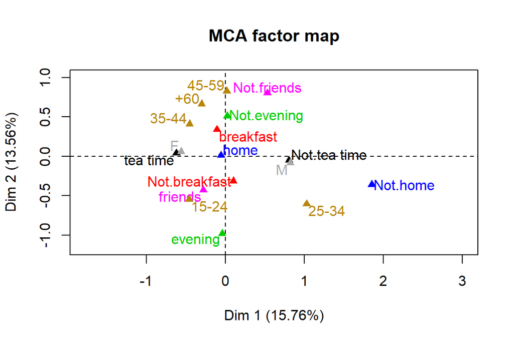

```r
# visualize MCA
plot(mca, invisible=c("ind"), graph.type = "classic", habillage = "quali")
```

From our results, we can see that our first two MCA dimensions do have clustering that involves age group and gender differences. On the first dimension, female respondents and tea time are weighted in one direction, and male respondents and no tea time are weighted in another. These variables do not contribute to the second dimension. On the second dimension, we have three oldest age groups, not friends, not evening, and breakfast weighted on one dimension. This would suggest that older respondents are more likely to enjoy tea alone, at breakfast, and not in the evening. On the other hand, the two youngest age groups show the opposite weighting on dimension two. Peculiarly, age group 25-34 and not home have a strong weight on dimension 1. This perhaps suggests that this specific age group, and more likely males who do not have a particular tea time, more commonly enjoy tea outside their home than the average respondent.

```
## [1] "Last updated Tue Dec 13 16:48:58 2022"
```

# Assignment 6: Analysis of longitudinal data

In this assignment we explore and analyze longitudinal data. First, we will use summary statistics to examine data from a nutrition study with three groups of rats on different diets. Second, we do a more formal analysis with linear mixed effects models of a data set where 40 male subjects were assigned to one of two treatment groups and rated on the brief psychiatric rating scale (BPRS). We will begin by taking a quick glance of rat nutrition study data, which we will refer to as RATS.

## Summary statistics approach

```r
# load in packages for future use, suppress output to keep course diary page tidy
library(readr) # install.packages("readr")
library(dplyr) # install.packages("dplyr")
library(tidyr) # install.packages("tidyr")
library(ggplot2) # install.packages("ggplot2")
library(lme4) # install.packages("lme4")
library(lmerTest) # install.packages("lmerTest")
library(patchwork) # install.packages("patchwork")
```

```r
# load in RATS data
RATS <- read.table("data/RATS.csv", sep = ",", header = T)

# take a look at the data
glimpse(RATS)
```

```
## Rows: 176
## Columns: 5
## $ ID     <int> 1, 2, 3, 4, 5, 6, 7, 8, 9, 10, 11, 12, 13, 14, 15, 16, 1, 2, 3,…
## $ Group  <int> 1, 1, 1, 1, 1, 1, 1, 1, 2, 2, 2, 2, 3, 3, 3, 3, 1, 1, 1, 1, 1, …
## $ WD     <chr> "WD1", "WD1", "WD1", "WD1", "WD1", "WD1", "WD1", "WD1", "WD1", …
## $ Weight <int> 240, 225, 245, 260, 255, 260, 275, 245, 410, 405, 445, 555, 470…
## $ Time   <int> 1, 1, 1, 1, 1, 1, 1, 1, 1, 1, 1, 1, 1, 1, 1, 1, 8, 8, 8, 8, 8, …
```

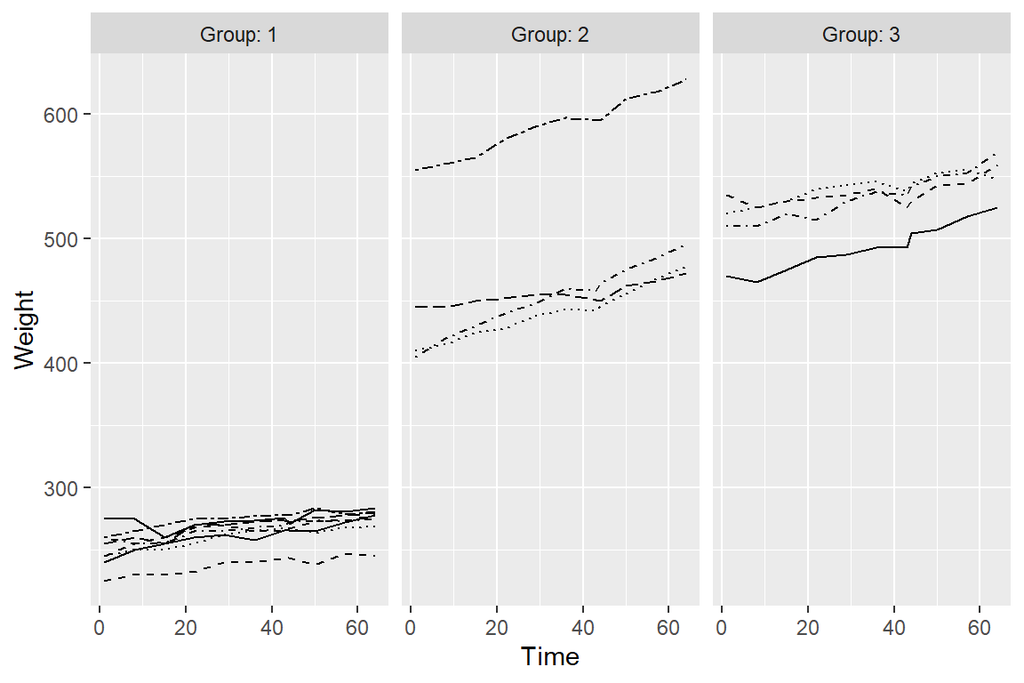

```r
# factor variables ID and Group
RATS$ID <- factor(RATS$ID)
RATS$Group <- factor(RATS$Group)

# draw plots for the three groups
ggplot(RATS, aes(x = Time, y = Weight, linetype = ID)) +
  geom_line() +
  scale_linetype_manual(values = unique(RATS$ID)) +
  facet_grid(. ~ Group, labeller = label_both) +
  theme(legend.position = "none") +
  scale_y_continuous(limits = c(min(RATS$Weight), max(RATS$Weight)))
```

In the data we have eight rats in group one, and four rats each in groups two and three. The starting weight of the rats is visibly lower in group one than it is in groups two and three. There is a general trend of increasing weight over the duration of the study. There would also seem to be a difference in weight from the starting point to the end, with lower rate of growth in group one compared to the other two. Also of note is a clear outlier in group two on the basis of starting weight.

A tracking phenomenon can be seen in the plotted data, meaning rats with higher starting weight tend to have a higher weight at the end of the study and vice versa. To visualize this even more clearly, we repeat the plot with standardized weight values.

```r
# standardise the variable Weight
RATS <- RATS %>%
  group_by(Time) %>%
  mutate(stdWeight = as.numeric(scale(Weight))) %>%
  ungroup()

# take a look at the data
glimpse(RATS)
```

```
## Rows: 176
## Columns: 6
## $ ID        <fct> 1, 2, 3, 4, 5, 6, 7, 8, 9, 10, 11, 12, 13, 14, 15, 16, 1, 2,…
## $ Group     <fct> 1, 1, 1, 1, 1, 1, 1, 1, 2, 2, 2, 2, 3, 3, 3, 3, 1, 1, 1, 1, …
## $ WD        <chr> "WD1", "WD1", "WD1", "WD1", "WD1", "WD1", "WD1", "WD1", "WD1…
## $ Weight    <int> 240, 225, 245, 260, 255, 260, 275, 245, 410, 405, 445, 555, …
## $ Time      <int> 1, 1, 1, 1, 1, 1, 1, 1, 1, 1, 1, 1, 1, 1, 1, 1, 8, 8, 8, 8, …
## $ stdWeight <dbl> -1.0011429, -1.1203857, -0.9613953, -0.8421525, -0.8819001, …
```

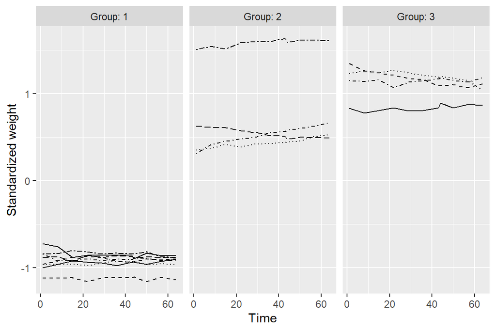

```r
# draw plots again with the standardised Weight
ggplot(RATS, aes(x = Time, y = stdWeight, linetype = ID)) +
  geom_line() +
  scale_linetype_manual(values = unique(RATS$ID)) +
  facet_grid(. ~ Group, labeller = label_both) +
  theme(legend.position = "none") +
  scale_y_continuous(name = "Standardized weight")
```

The tracking phenomenon is most apparent with rats that differ from their respective group mean.

Next, we will move on from examining data of individual rats to exploration of summary measures for different groups. For this, we will calculate means and standard errors within groups for all different time points. We will plot the summary data as a line graph with error bars, and as boxplots which are more descriptive of distribution and outliers.

```r
# calculate summary data for time points by group
RATSS <- RATS %>%
  group_by(Group, Time) %>%
  summarise( mean = mean(Weight), se = sd(Weight)/sqrt(length(unique(ID))) ) %>%
  ungroup()
# take a look at the data
glimpse(RATSS)
```

```
## Rows: 33
## Columns: 4
## $ Group <fct> 1, 1, 1, 1, 1, 1, 1, 1, 1, 1, 1, 2, 2, 2, 2, 2, 2, 2, 2, 2, 2, 2…
## $ Time  <int> 1, 8, 15, 22, 29, 36, 43, 44, 50, 57, 64, 1, 8, 15, 22, 29, 36, …
## $ mean  <dbl> 250.625, 255.000, 254.375, 261.875, 264.625, 265.000, 267.375, 2…
## $ se    <dbl> 5.381640, 4.629100, 4.057346, 4.808614, 3.909409, 4.166190, 3.87…
```

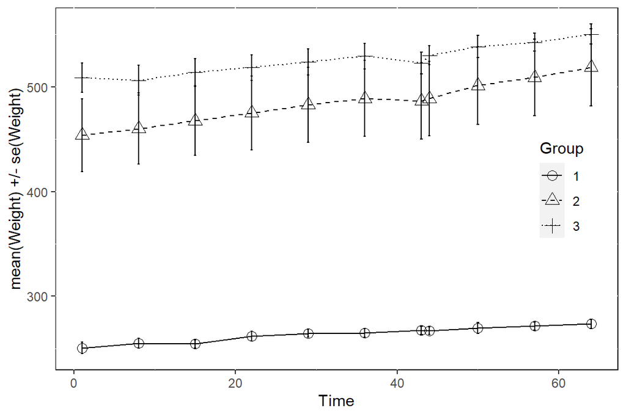

```r
# plot the mean profiles
ggplot(RATSS, aes(x = Time, y = mean, linetype = Group, shape = Group)) +
  geom_line() +
  scale_linetype_manual(values = c(1,2,3)) +
  geom_point(size=3) +
  scale_shape_manual(values = c(1,2,3)) +
  geom_errorbar(aes(ymin=mean-se, ymax=mean+se, linetype="1"), width=0.3) +
  theme(legend.position = c(0.9,0.5)) +
  scale_y_continuous(name = "mean(Weight) +/- se(Weight)") +
  theme(panel.background = element_rect(fill = "white", colour = "black"))
```

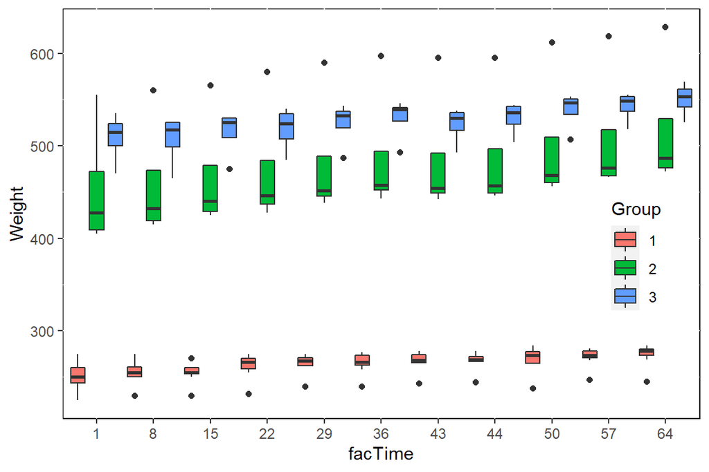

```r
# plot the mean profiles with boxplots
RATS$facTime <- factor(RATS$Time)
ggplot(RATS, aes(x = facTime, y = Weight, fill = Group)) +
  geom_boxplot(position=position_dodge(1)) +
  theme(legend.position = c(0.9,0.4)) +
  scale_y_continuous(name = "Weight") +
  theme(panel.background = element_rect(fill = "white", colour = "black"))
```

Our main interest with this data is whether there is a difference in **growth** between the three nutrition groups. Thus, a suitable summary statistic would be the average difference between the first and last weight measurements. We will calculate such a statistic for the three groups and draw boxplots for visual examination.

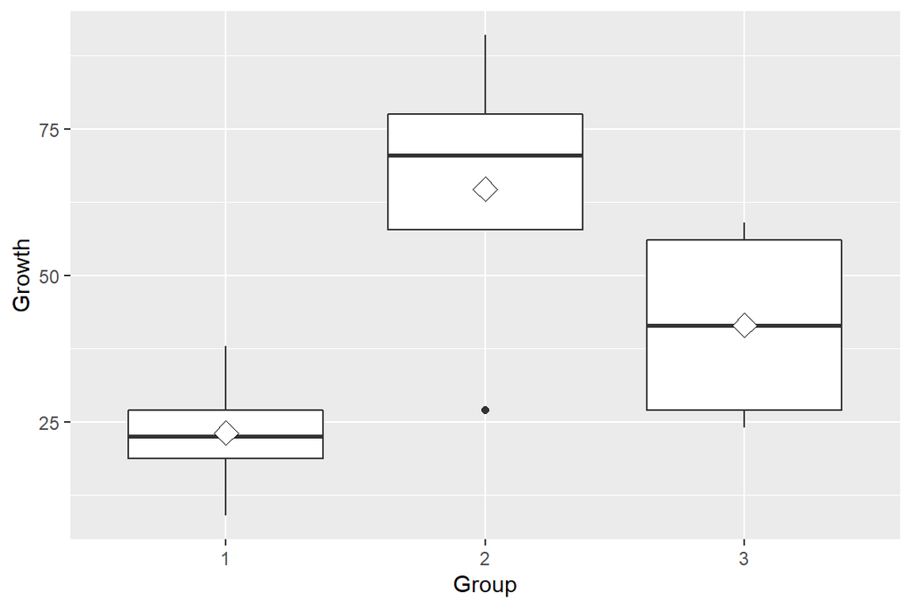

```r
# create a data frame with the difference of weights between last and first measurement
RATSlast <- filter(RATS, Time == max(Time)) %>%
  transmute(lastWeight = Weight)
RATSdiff <- filter(RATS, Time == min(Time)) %>%
  transmute(ID = ID, Group = Group, firstWeight = Weight, lastWeight = RATSlast$lastWeight, weightDiff = lastWeight - firstWeight)

# draw boxplots of weight difference ("Growth") for the three groups
ggplot(RATSdiff, aes(x = Group, y = weightDiff)) +
  geom_boxplot() +
  stat_summary(fun = "mean", geom = "point", shape=23, size=4, fill = "white") +
  scale_y_continuous(name = "Growth")
```

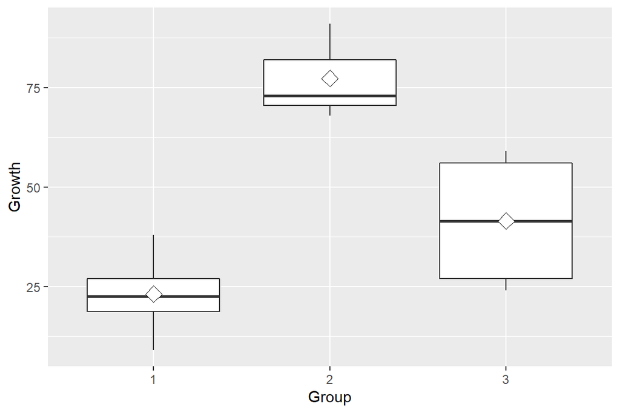

```r
# indicator for outlier
RATSdiff$outlier <- RATSdiff$Group == 2 & RATSdiff$weightDiff < 40

# create new data excluding outlier
RATSdiff2 <- RATSdiff %>% filter(RATSdiff$outlier != TRUE)

# draw new boxplots
ggplot(RATSdiff2, aes(x = Group, y = weightDiff)) +
  geom_boxplot() +
  stat_summary(fun = "mean", geom = "point", shape=23, size=4, fill = "white") +
  scale_y_continuous(name = "Growth")
```

Based on the first graph, there was an outlier in our growth measure in group two. After removing the outlier we plot the data again. The general finding is that group one has the lowest growth in weight, group two has the highest growth in weight, with group three in the middle. Also of note is that group three has the highest variability in the growth measure.

To more formally test for the statistical significance of the difference between groups, we will now run two-sample t-tests between each group pair. Finally, for completion and to keep in line with analyses conducted in “MABS4IODS”, we will run analysis of covariance

```r
# two-sample t-test between groups 1 and 2
t.test(weightDiff ~ Group, data = filter(RATSdiff2, Group != 3), var.equal = TRUE)
```

```
##
##  Two Sample t-test
##
## data:  weightDiff by Group
## t = -8.027, df = 9, p-value = 2.155e-05
## alternative hypothesis: true difference in means between group 1 and group 2 is not equal to 0
## 95 percent confidence interval:
##  -69.48523 -38.93144
## sample estimates:
## mean in group 1 mean in group 2
##        23.12500        77.33333
```

```r
# two-sample t-test between groups 1 and 3
t.test(weightDiff ~ Group, data = filter(RATSdiff2, Group != 2), var.equal = TRUE)
```

```
##
##  Two Sample t-test
##
## data:  weightDiff by Group
## t = -2.3873, df = 10, p-value = 0.03814
## alternative hypothesis: true difference in means between group 1 and group 3 is not equal to 0
## 95 percent confidence interval:
##  -35.525202  -1.224798
## sample estimates:
## mean in group 1 mean in group 3
##          23.125          41.500
```

```r
# two-sample t-test between groups 2 and 3
t.test(weightDiff ~ Group, data = filter(RATSdiff2, Group != 1), var.equal = TRUE)
```

```
##
##  Two Sample t-test
##
## data:  weightDiff by Group
## t = 2.9442, df = 5, p-value = 0.0321
## alternative hypothesis: true difference in means between group 2 and group 3 is not equal to 0
## 95 percent confidence interval:
##   4.547359 67.119308
## sample estimates:
## mean in group 2 mean in group 3
##        77.33333        41.50000
```

```r
# fit linear model
fit <- lm(weightDiff ~ firstWeight + Group, data = RATSdiff2)

# compute anova
anova(fit)
```

```
## Analysis of Variance Table
##
## Response: weightDiff
##             Df Sum Sq Mean Sq F value    Pr(>F)
## firstWeight  1 2521.1 2521.09  17.712 0.0014643 **
## Group        2 4234.9 2117.47  14.877 0.0007444 ***
## Residuals   11 1565.7  142.34
## ---
## Signif. codes:  0 '***' 0.001 '**' 0.01 '*' 0.05 '.' 0.1 ' ' 1
```

From the two-sample t-tests we can determine that all three groups have a statistically significant difference in growth of weight. The analysis of covariance further shows that there is a statistically significant difference in both baseline weight and weight change by group. Note, however, that this is an omnibus test, and only indicates that there is a difference *at least* between some of the three groups.

## Linear mixed effects model approach

For the next part, we will load in the data on psychological treatment and brief psychiatric rating scale scores (BPRS). First, we will examine the data briefly, and visualize it using three different styles of plots.

```r
# load BPRS data
BPRS <- read.table("data/BPRS.csv", sep = ",", header = T)

# take a look at the data
glimpse(BPRS)
```

```
## Rows: 360
## Columns: 5
## $ treatment <int> 1, 1, 1, 1, 1, 1, 1, 1, 1, 1, 1, 1, 1, 1, 1, 1, 1, 1, 1, 1, …
## $ subject   <int> 1, 2, 3, 4, 5, 6, 7, 8, 9, 10, 11, 12, 13, 14, 15, 16, 17, 1…
## $ weeks     <chr> "week0", "week0", "week0", "week0", "week0", "week0", "week0…
## $ bprs      <int> 42, 58, 54, 55, 72, 48, 71, 30, 41, 57, 30, 55, 36, 38, 66, …
## $ week      <int> 0, 0, 0, 0, 0, 0, 0, 0, 0, 0, 0, 0, 0, 0, 0, 0, 0, 0, 0, 0, …
```

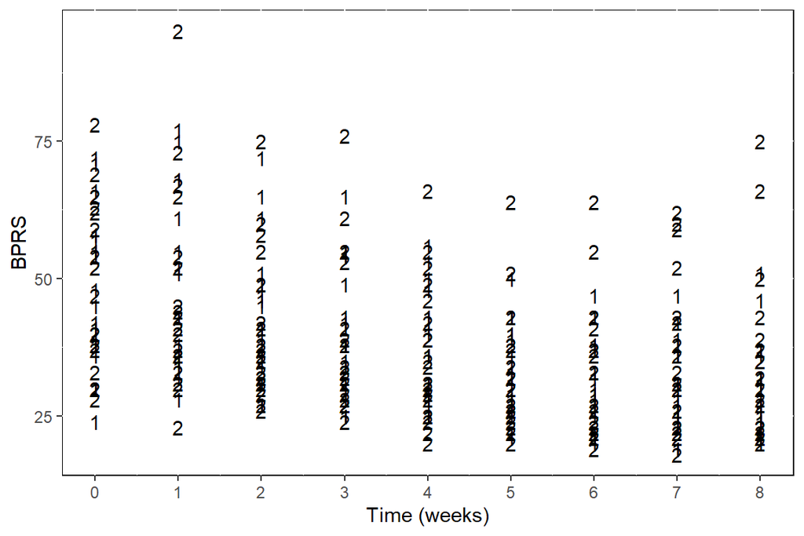

```r
# adjust subject numbers so that they are unique
BPRS$subject[BPRS$treatment == 2] <- BPRS$subject[BPRS$treatment == 2] + 20

# treatment and subject as factors
BPRS$treatment <- factor(BPRS$treatment)
BPRS$subject <- factor(BPRS$subject)

# plot all bprs scores with treatment number
ggplot(BPRS, aes(x = week, y = bprs)) +
  geom_text(aes(label = treatment)) +
  scale_x_continuous(name = "Time (weeks)", breaks = seq(0, 8, 1)) +
  scale_y_continuous(name = "BPRS") +
  theme(legend.position = "top") +
  theme(panel.background = element_rect(fill = "white", colour = "black"))
```

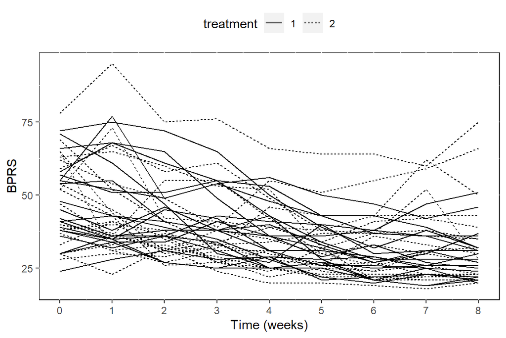

```r
# plot all subjects with line style by treatment
ggplot(BPRS, aes(x = week, y = bprs, group = subject)) +
  geom_line(aes(linetype = treatment)) +
  scale_x_continuous(name = "Time (weeks)", breaks = seq(0, 8, 1)) +
  scale_y_continuous(name = "BPRS") +
  theme(legend.position = "top") +
  theme(panel.background = element_rect(fill = "white", colour = "black"))
```

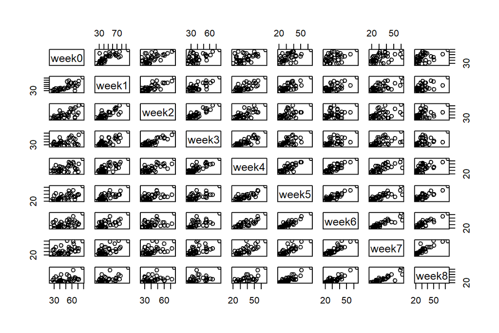

```r
# create new data frame to plot pairs() of bprs by week
week0 <- BPRS$bprs[BPRS$week == 0]
week1 <- BPRS$bprs[BPRS$week == 1]
week2 <- BPRS$bprs[BPRS$week == 2]
week3 <- BPRS$bprs[BPRS$week == 3]
week4 <- BPRS$bprs[BPRS$week == 4]
week5 <- BPRS$bprs[BPRS$week == 5]
week6 <- BPRS$bprs[BPRS$week == 6]
week7 <- BPRS$bprs[BPRS$week == 7]
week8 <- BPRS$bprs[BPRS$week == 8]
BPRSweeks <- data.frame(week0, week1, week2, week3, week4, week5, week6, week7, week8)

# scatterplot matrix of bprs
pairs(BPRSweeks)
```

From the first two plots we can see that there is a general trend of lowering BPRS scores with the study duration. There is also large variation in individual BPRS starting scores, and that this variation is smaller at the end of the study. However, it is difficult to see a clear difference between the two treatment groups. From the scatterplot matrix we can see that there is a higher correlation in BPRS scores the closer together the two times of measurement are. This makes intuitive sense, as the change is expected to be gradual.

Next, we will fit a variety of different models to the data, with BPRS score as the response variable, and week and treatment as explanatory variables. Summaries of the model are then provided. First, a linear regression model that ignores the repeated-measures structure of the data is fit. Second, a linear mixed effects model with random intercept is fit. Third, a random intercept and random slope model is fit. Fourth, a random intercept and random slope model with interaction between week and treatment is fit. ANOVA tests between models two and three, and between models three and four, are performed to investigate if the more complex models provide a statistically significant improvement on fit.

```r
# linear regression model ignoring repeated-measures structure
BPRSreg1 <- lm(bprs ~ week + treatment, data = BPRS)

# print out a summary of the model
summary(BPRSreg1)
```

```
##
## Call:
## lm(formula = bprs ~ week + treatment, data = BPRS)
##
## Residuals:
##     Min      1Q  Median      3Q     Max
## -22.454  -8.965  -3.196   7.002  50.244
##
## Coefficients:
##             Estimate Std. Error t value Pr(>|t|)
## (Intercept)  46.4539     1.3670  33.982   <2e-16 ***
## week         -2.2704     0.2524  -8.995   <2e-16 ***
## treatment2    0.5722     1.3034   0.439    0.661
## ---
## Signif. codes:  0 '***' 0.001 '**' 0.01 '*' 0.05 '.' 0.1 ' ' 1
##
## Residual standard error: 12.37 on 357 degrees of freedom
## Multiple R-squared:  0.1851, Adjusted R-squared:  0.1806
## F-statistic: 40.55 on 2 and 357 DF,  p-value: < 2.2e-16
```

```r
# random intercept model
BPRSreg2 <- lmer(bprs ~ week + treatment + (1 | subject), data = BPRS, REML = FALSE)

# Print the summary of the model
summary(BPRSreg2)
```

```
## Linear mixed model fit by maximum likelihood . t-tests use Satterthwaite's
##   method [lmerModLmerTest]
## Formula: bprs ~ week + treatment + (1 | subject)
##    Data: BPRS
##
##      AIC      BIC   logLik deviance df.resid
##   2582.9   2602.3  -1286.5   2572.9      355
##
## Scaled residuals:
##      Min       1Q   Median       3Q      Max
## -2.27506 -0.59909 -0.06104  0.44226  3.15835
##
## Random effects:
##  Groups   Name        Variance Std.Dev.
##  subject  (Intercept) 97.39    9.869
##  Residual             54.23    7.364
## Number of obs: 360, groups:  subject, 40
##
## Fixed effects:
##             Estimate Std. Error       df t value Pr(>|t|)
## (Intercept)  46.4539     2.3521  45.7607  19.750   <2e-16 ***
## week         -2.2704     0.1503 320.0000 -15.104   <2e-16 ***
## treatment2    0.5722     3.2159  40.0000   0.178     0.86
## ---
## Signif. codes:  0 '***' 0.001 '**' 0.01 '*' 0.05 '.' 0.1 ' ' 1
##
## Correlation of Fixed Effects:
##            (Intr) week
## week       -0.256
## treatment2 -0.684  0.000
```

```r
# random intercept and random slope model
BPRSreg3 <- lmer(bprs ~ week + treatment + (week | subject), data = BPRS, REML = FALSE)

# print a summary of the model
summary(BPRSreg3)
```

```
## Linear mixed model fit by maximum likelihood . t-tests use Satterthwaite's
##   method [lmerModLmerTest]
## Formula: bprs ~ week + treatment + (week | subject)
##    Data: BPRS
##
##      AIC      BIC   logLik deviance df.resid
##   2523.2   2550.4  -1254.6   2509.2      353
##
## Scaled residuals:
##     Min      1Q  Median      3Q     Max
## -2.4655 -0.5150 -0.0920  0.4347  3.7353
##
## Random effects:
##  Groups   Name        Variance Std.Dev. Corr
##  subject  (Intercept) 167.827  12.955
##           week          2.331   1.527   -0.67
##  Residual              36.747   6.062
## Number of obs: 360, groups:  subject, 40
##
## Fixed effects:
##             Estimate Std. Error      df t value Pr(>|t|)
## (Intercept)  45.9830     2.6470 49.9491  17.372  < 2e-16 ***
## week         -2.2704     0.2713 40.0001  -8.370 2.51e-10 ***
## treatment2    1.5139     3.1392 39.9998   0.482    0.632
## ---
## Signif. codes:  0 '***' 0.001 '**' 0.01 '*' 0.05 '.' 0.1 ' ' 1
##
## Correlation of Fixed Effects:
##            (Intr) week
## week       -0.545
## treatment2 -0.593  0.000
```

```r
# perform an ANOVA test on the two models
anova(BPRSreg2, BPRSreg3)
```

```
## Data: BPRS
## Models:
## BPRSreg2: bprs ~ week + treatment + (1 | subject)
## BPRSreg3: bprs ~ week + treatment + (week | subject)
##          npar    AIC    BIC  logLik deviance  Chisq Df Pr(>Chisq)
## BPRSreg2    5 2582.9 2602.3 -1286.5   2572.9
## BPRSreg3    7 2523.2 2550.4 -1254.6   2509.2 63.663  2  1.499e-14 ***
## ---
## Signif. codes:  0 '***' 0.001 '**' 0.01 '*' 0.05 '.' 0.1 ' ' 1
```

```r
# random intercept and random slope model with interaction
BPRSreg4 <- lmer(bprs ~ week * treatment + (week | subject), data = BPRS, REML = FALSE)

# print a summary of the model
summary(BPRSreg4)
```

```
## Linear mixed model fit by maximum likelihood . t-tests use Satterthwaite's
##   method [lmerModLmerTest]
## Formula: bprs ~ week * treatment + (week | subject)
##    Data: BPRS
##
##      AIC      BIC   logLik deviance df.resid
##   2523.5   2554.5  -1253.7   2507.5      352
##
## Scaled residuals:
##     Min      1Q  Median      3Q     Max
## -2.4747 -0.5256 -0.0866  0.4435  3.7884
##
## Random effects:
##  Groups   Name        Variance Std.Dev. Corr
##  subject  (Intercept) 164.204  12.814
##           week          2.203   1.484   -0.66
##  Residual              36.748   6.062
## Number of obs: 360, groups:  subject, 40
##
## Fixed effects:
##                 Estimate Std. Error      df t value Pr(>|t|)
## (Intercept)      47.8856     2.9840 40.0010  16.047  < 2e-16 ***
## week             -2.6283     0.3752 40.0021  -7.006 1.84e-08 ***
## treatment2       -2.2911     4.2200 40.0010  -0.543    0.590
## week:treatment2   0.7158     0.5306 40.0021   1.349    0.185
## ---
## Signif. codes:  0 '***' 0.001 '**' 0.01 '*' 0.05 '.' 0.1 ' ' 1
##
## Correlation of Fixed Effects:
##             (Intr) week   trtmn2
## week        -0.668
## treatment2  -0.707  0.473
## wek:trtmnt2  0.473 -0.707 -0.668
```

```r
# perform an ANOVA test on the two models
anova(BPRSreg3, BPRSreg4)
```

```
## Data: BPRS
## Models:
## BPRSreg3: bprs ~ week + treatment + (week | subject)
## BPRSreg4: bprs ~ week * treatment + (week | subject)
##          npar    AIC    BIC  logLik deviance Chisq Df Pr(>Chisq)
## BPRSreg3    7 2523.2 2550.4 -1254.6   2509.2
## BPRSreg4    8 2523.5 2554.6 -1253.7   2507.5  1.78  1     0.1821
```

With all of the above models, a common pattern is that time of measurement (week) is a significant predictor for BPRS score, while treatment group is not. Moving from the first to the second model, a large portion is correctly assigned from residual variance to inter-subject variance in intercept (in random effects). Adding the random slope in model three does assign a small portion of variance to inter-subject difference, which does increase the coefficient of treatment group two in comparison to one slightly. However, treatment group still does not become a statistically significant predictor. A look at model goodness-of-fit criteria between models two and three (and more formally, the ANOVA test) shows that allowing random slope in the model provides a better fit. Including interaction between week and treatment in model four does change the coefficients around slightly, with a negative weight for treatment, and a positive weight for the interaction. However, neither is statistically significant. Finally, comparing model three and model four, we can see that model four does not provide improvement in fit over model three. The goodness-of-fit criteria are essentially the same between the two models.

As a final step in our analysis, we will extract fitted BPRS values from our model. As there is no improvement with model four over model three, we will use the more parsimonious model three. We will then plot observed BPRS values next to the fitted ones to examine how well our model fit aligns with ground truth.

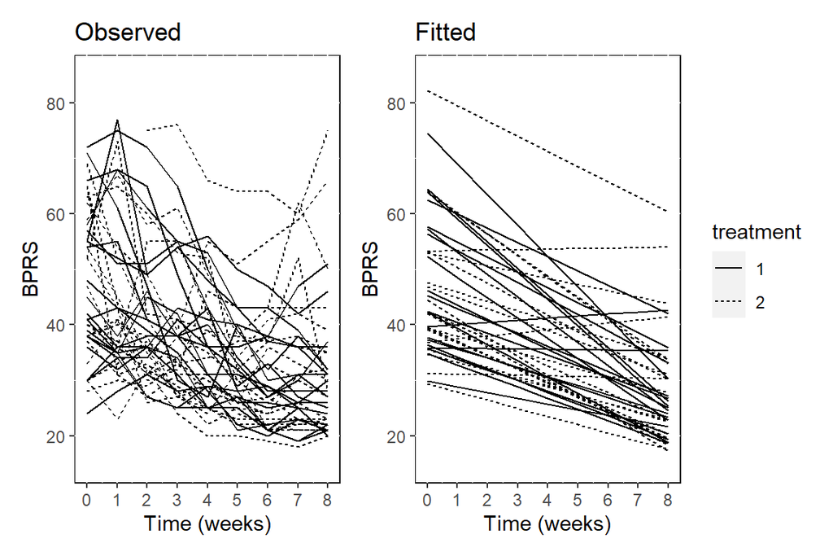

```r
# create vector with fitted values
Fitted <- as.numeric(fitted(BPRSreg3))

# new column with fitted values
BPRS <- BPRS %>% mutate( fitted = Fitted )

# plot of observed values
p1 <- ggplot(BPRS, aes(x = week, y = bprs, group = subject)) +
  geom_line(aes(linetype = treatment)) +
  scale_x_continuous(name = "Time (weeks)", breaks = seq(0, 8, 1)) +
  scale_y_continuous(name = "BPRS", limits = c(15, 85)) +
  theme(legend.position = "none") +
  theme(panel.background = element_rect(fill = "white", colour = "black")) +
  labs(title = "Observed")

# plot of fitted values
p2 <- ggplot(BPRS, aes(x = week, y = fitted, group = subject)) +
  geom_line(aes(linetype = treatment)) +
  scale_x_continuous(name = "Time (weeks)", breaks = seq(0, 8, 1)) +
  scale_y_continuous(name = "BPRS", limits = c(15, 85)) +
  theme(legend.position = "right") +
  theme(panel.background = element_rect(fill = "white", colour = "black")) +
  labs(title = "Fitted")

p1 + p2
```

From the graph we can see that the model fit captures the general trend in BPRS change decently well. As the fit is linear, it obviously disregards the week-to-week fluctuation seen in the real data. Arguably, the overall change over the study duration is a more relevant, and simple statistic when evaluating treatment outcomes.

```
## [1] "Last updated Tue Dec 13 16:49:02 2022"
```

(more chapters to be added similarly as we proceed with the course!)